An Introduction to oTree Questionnaires and individual decision making Matteo Ploner (UNITN)

# Forms

## Submitting information

- Each page in oTree can contain a **form**
  - The player fills with some value and then submits it
    - Cardinal values
      - Integer, Float
    - Ordinal values
      - Integer, Categorical
    - Text
      - Strings of numbers and letters
- Several formats to collect values
  - Open fiels
  - Buttons
  - Radio buttons
  - Dropdown lists
  - …

## Basic structure of forms

- First create fields in *models.py*
- As an example, if you want to collect name and age

```bash
class Player(BasePlayer):
    name = models.StringField(label="Your name:")
    age = models.IntegerField(label="Your age:")
```

- Then in *pages.py*, you will create a class

```bash
class Anag(Page):
    form_model = 'player'
    form_fields = ['name', 'age'] # saved as player.name, player.age
```

- Finally, in the template *Anag.html* the form will be displayed with

```bash
{% formfields %}
```

- To display the forms separately

```bash
{% formfields player.age %}
```

# Input formats

## Examples

- In the following examples the participant receives a random number
- The participant is asked to report features of the number
  - Several input interfaces are presented
    - Radio
    - Button
    - Checker
    - Dropdown
    - Radio Sequence
    - Text
    - Value
    - Tabular
    - Sliders

## Radio

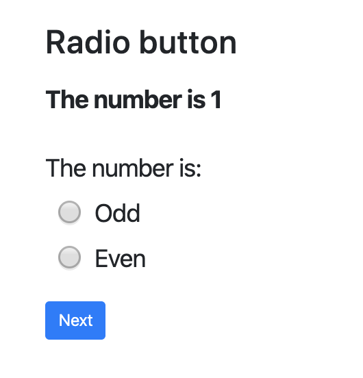

- Models

```python
input_radio = models.CharField(
    choices=['Odd', 'Even'],
    widget=widgets.RadioSelect)
```

- Pages

```python
class Radio(Page):
    form_model = 'player'
    form_fields = ['input_radio']
```

- Template

```html
{% block content %}

{% formfield player.input_radio label="The number is:"%}

  {% next_button %}

{% endblock %}
```

## Button

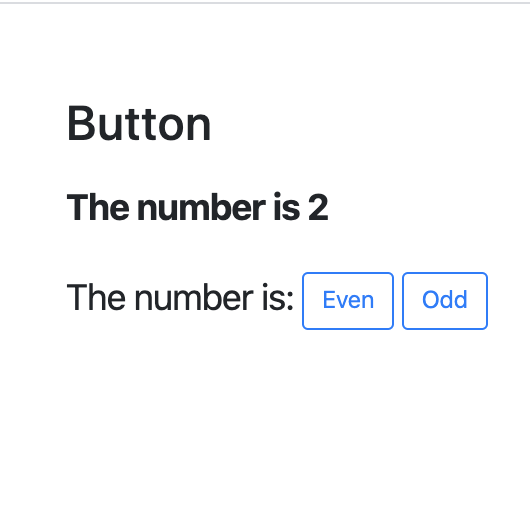

- Models

```python
class Player(BasePlayer):
    input_button = models.CharField()
```

- Pages

```python
class Button(Page):
    form_model = 'player'
    form_fields = ['input_button']
```

- Template
  - This widget does not rely on oTree functionalities
  - Raw HTML with *bootstrap* features

```html
{% block content %}

The number is:
<button name="input_button" value="Even" class="btn btn-outline-primary" btn-lg">Even</button>
<button name="input_button" value="Odd" class="btn btn-outline-primary" btn-lg">Odd</button>

{% endblock %}
```

## Checker

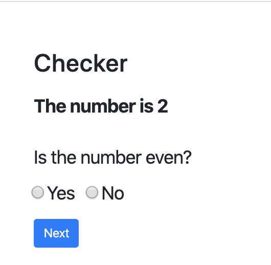

- Models

```python
class Player(BasePlayer):
  input_checker = models.CharField(
    choices=[
            ["Even", 'Yes'],
            ["Odd", 'No']
            ],
    widget=widgets.RadioSelectHorizontal,
    label="Is the number even?")
```

- Pages

```python
class Checker(Page):
    form_model = 'player'
    form_fields = ['input_checker']
```

- Template

```html
{% block content %}

{% formfield player.input_checker %}

    {% next_button %}

{% endblock %}
```

## Dropdown

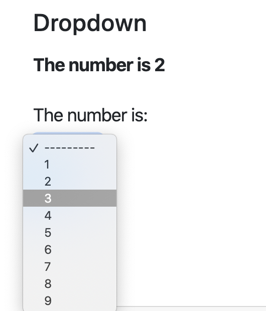

- Models

```python
class Player(BasePlayer):
    input_dropdown = models.IntegerField(
    choices=[1, 2, 3, 4, 5, 6, 7, 8, 9])
```

- Pages

```python
class Dropdown(Page):
    form_model = 'player'
    form_fields = ['input_dropdown']
```

- Template

```html
{% block content %}

{% formfield player.input_dropdown label="The number is:"%}

    {% next_button %}

{% endblock %}
```

## Radiosequence

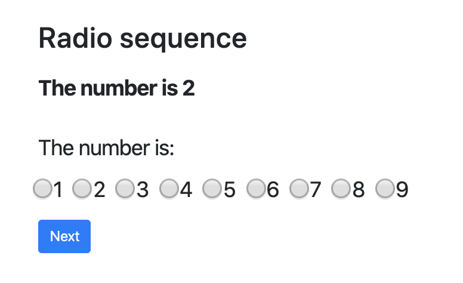

- Models

```python
class Player(BasePlayer):
    input_radiosequence = models.IntegerField(
        choices=[1, 2, 3, 4, 5, 6, 7, 8, 9],
        widget=widgets.RadioSelectHorizontal
        )
```

- Pages

```python
class RadioSequence(Page):
    form_model = 'player'
    form_fields = ['input_radiosequence']
```

- Template

```html
{% block content %}

{% formfield player.input_radiosequence label="The number is:"%}

    {% next_button %}

{% endblock %}
```

## Text

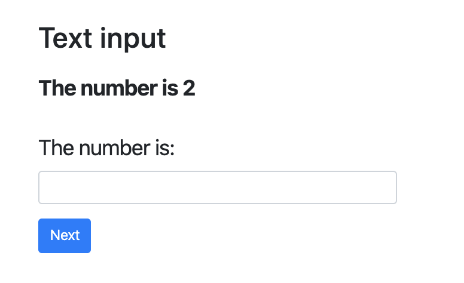

- Models

```python
class Player(BasePlayer):
    input_text = models.CharField()
```

- Pages

```python
class Text(Page):
    form_model = 'player'
    form_fields = ['input_text']
```

- Template

```html
{% block content %}

{% formfield player.input_text label="The number is:"%}

    {% next_button %}

{% endblock %}
```

## Value

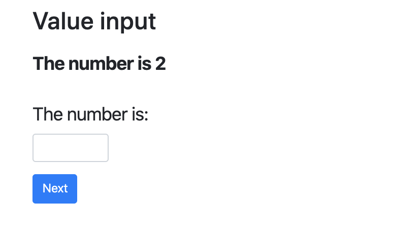

- Models

```python
class Player(BasePlayer):
    input_value = models.IntegerField(min=1, max=9)
```

- Pages

```python
class Value(Page):
    form_model = 'player'
    form_fields = ['input_value']
```

- Template

```html
{% block content %}

{% formfield player.input_value label="The number is:"%}

    {% next_button %}

{% endblock %}
```

## Tabular (i)

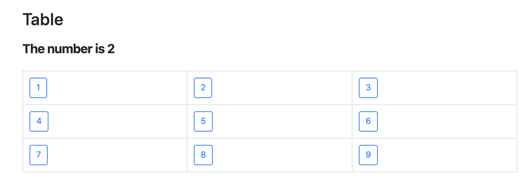

- Models

```python
class Player(BasePlayer):
    tab_1 = models.BooleanField(blank=True)
    tab_2 = models.BooleanField(blank=True)
    tab_3 = models.BooleanField(blank=True)
    tab_4 = models.BooleanField(blank=True)
    tab_5 = models.BooleanField(blank=True)
    tab_6 = models.BooleanField(blank=True)
    tab_7 = models.BooleanField(blank=True)
    tab_8 = models.BooleanField(blank=True)
    tab_9 = models.BooleanField(blank=True)
```

- Pages

```python
class Tabular(Page):
    form_model = 'player'
    form_fields = ['tab_1','tab_2','tab_3','tab_4','tab_5','tab_6','tab_7','tab_8','tab_9']
```

## Tabular (ii)

- Template
  - raw HTML, bs table

```html
{% block content %}

  <table class="table table-bordered">
    <tbody>
      <tr>
          <td><button name="tab_1" value="True" class="btn btn-outline-primary" btn-lg"> 1 </button></td>
          <td> <button name="tab_2" value="True" class="btn btn-outline-primary" btn-lg">2</button></td>
          <td> <button name="tab_3" value="True" class="btn btn-outline-primary" btn-lg">3</button></td>
        </tr>
        <tr>
          <td><button name="tab_4" value="True" class="btn btn-outline-primary" btn-lg">4</button></td>
          <td><button name="tab_5" value="True" class="btn btn-outline-primary" btn-lg">5</button></td>
          <td><button name="tab_6" value="True" class="btn btn-outline-primary" btn-lg">6</button></td>
      </tr>
      <tr>
        <td ><button name="tab_7" value="True" class="btn btn-outline-primary" btn-lg">7</button></td>
        <td><button name="tab_8" value="True" class="btn btn-outline-primary" btn-lg">8</button></td>
        <td><button name="tab_9" value="True" class="btn btn-outline-primary" btn-lg">9</button></td>
<!--    <td><button name="tab_8" value="True" class="btn btn-outline-primary" btn-lg">8</button></td> -->

      </tr>
    </tbody>
  </table>

{% endblock %}
```

## Slider (simple)

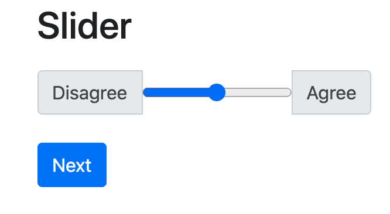

- Models

```python
input_slider = models.IntegerField(min=1, max=9)
```

- Pages

```python
class Slider(Page):
    form_model = 'player'
    form_fields = ['input_slider']
```

- Template

```html
<div class="input-group">
    <div class="input-group-prepend">
        <span class="input-group-text">Disagree</span>
    </div>

    <input type="range" name="input_slider" min="1" max="9" step="1">

    <div class="input-group-append">
        <span class="input-group-text">Agree</span>
    </div>
</div>

{{ form.input_slider.errors }}
```

## Slider (boosted by css)

[figure not shown]

- Template

```html
<div class="float-left labels"> Very much</div>
<div class="float-right labels">Not at all</div>
 <input type="range" min="1" max="9" class="slider" id="MyRange" name="input_slider" value="5">
```

- improve the look with `.css style`

```html
{% block styles %}

<style>
    .myDiv {
        border: 0px outset red;
        background-color: #ebebeb;
        text-align: center;
        padding: 15px;
    }

    .slidecontainer {
        width: 100%;
        /* Width of the outside container */
    }

    /* The slider itself */
    .slider {
        -webkit-appearance: none;
        /* Override default CSS styles */
        appearance: none;
        width: 100%;
        /* Full-width */
        height: 25px;
        /* Specified height */
        background: #d3d3d3;
        /* Grey background */
        outline: .1;
        /* Remove outline */
        opacity: 0.7;
        /* Set transparency (for mouse-over effects on hover) */
        -webkit-transition: .2s;
        /* 0.2 seconds transition on hover */
        transition: opacity .2s;
    }

    /* Mouse-over effects */
    .slider:hover {
        opacity: 1;
        /* Fully shown on mouse-over */
    }

    /* The slider handle (use -webkit- (Chrome, Opera, Safari, Edge) and -moz- (Firefox) to override default look) */
    .slider::-webkit-slider-thumb {
        -webkit-appearance: none;
        /* Override default look */
        appearance: none;
        width: 50px;
        /* Set a specific slider handle width */
        height: 25px;
        /* Slider handle height */
        background: #4CAF50;
        /* Green background */
        cursor: pointer;
        /* Cursor on hover */
    }

    .slider::-moz-range-thumb {
        width: 25px;
        /* Set a specific slider handle width */
        height: 25px;
        /* Slider handle height */
        background: #4CAF50;
        /* Green background */
        cursor: pointer;
        /* Cursor on hover */
    }
</style>
{% endblock %}
```

# Setting up an individual decision-making task

## Our app

1. we investigate individuals’ risk attituted
   - Multiple Price List (MPL) questionnaire [@holt2002risk]
     - Trade-off between lotteries
2. we collect pieces of demographic information
   - Age, gender, …

## Risk attitudes

- A Multiple Price List format

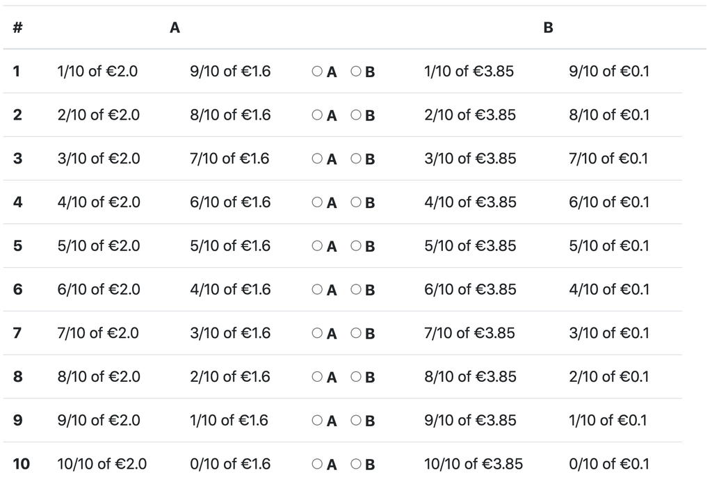

- For each pair of options the participants they should choose A or B
  - Option A is safer than corresponding Option B
  - The attractiveness of Option B in terms of relative expected payoffs increases when scrolling down to the bottom of the table
- A risk-neutral decision maker should switch from A to B at $5^{th}$ choice
  - Choosing A at $10^{th}$ choice is dominated for all preference types
- One row is randomly selected and outcomes paid

## Screens

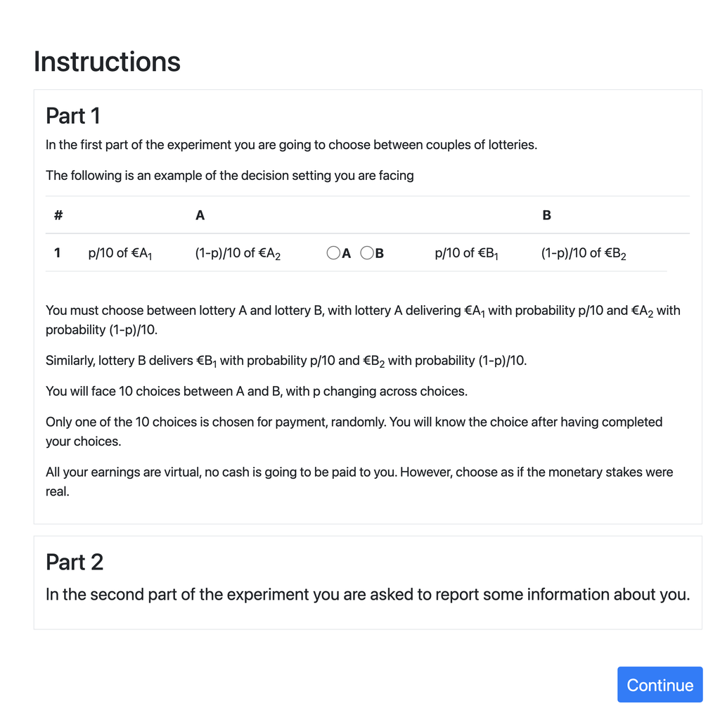

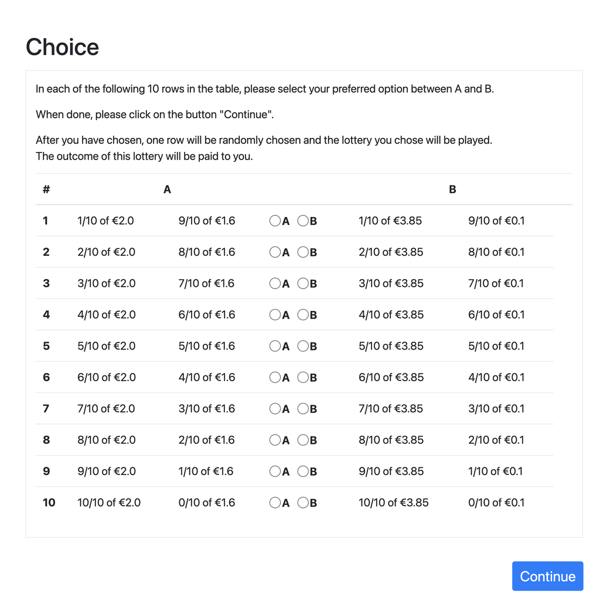

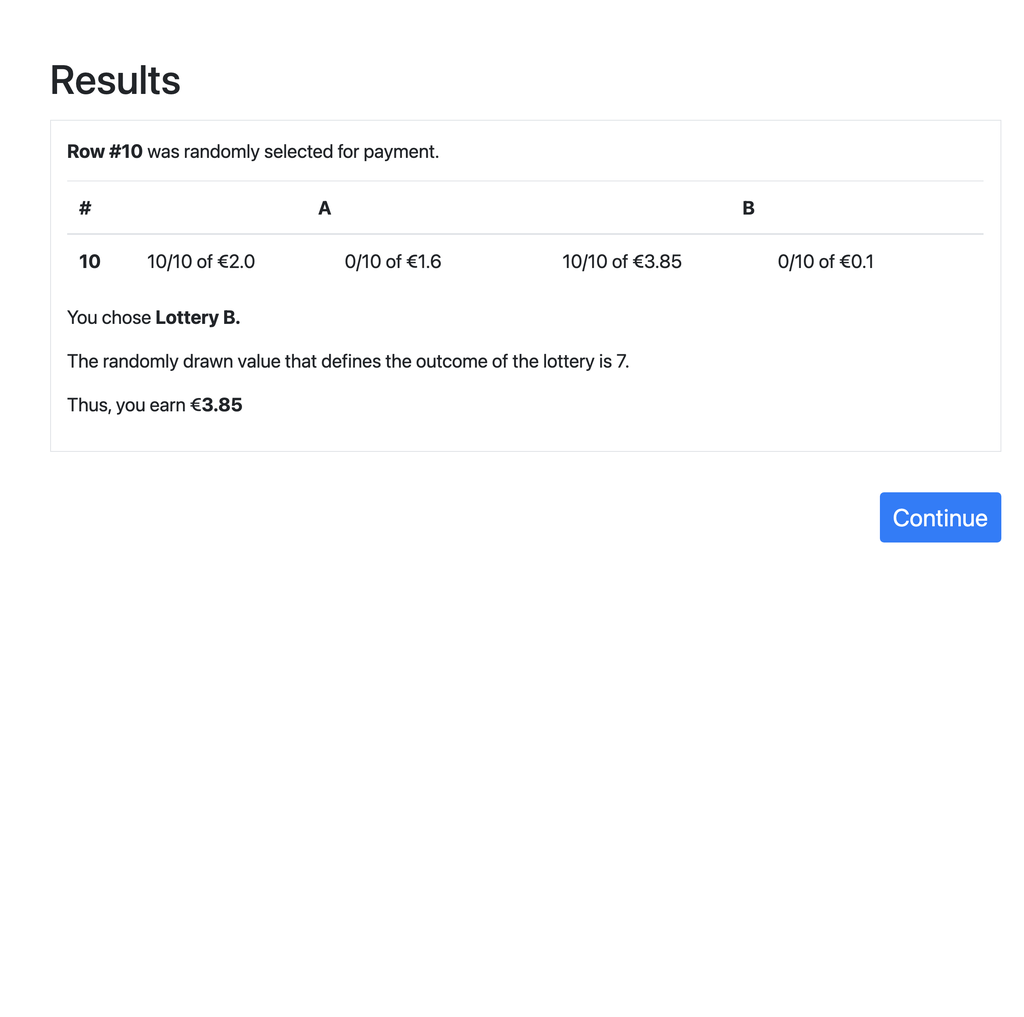

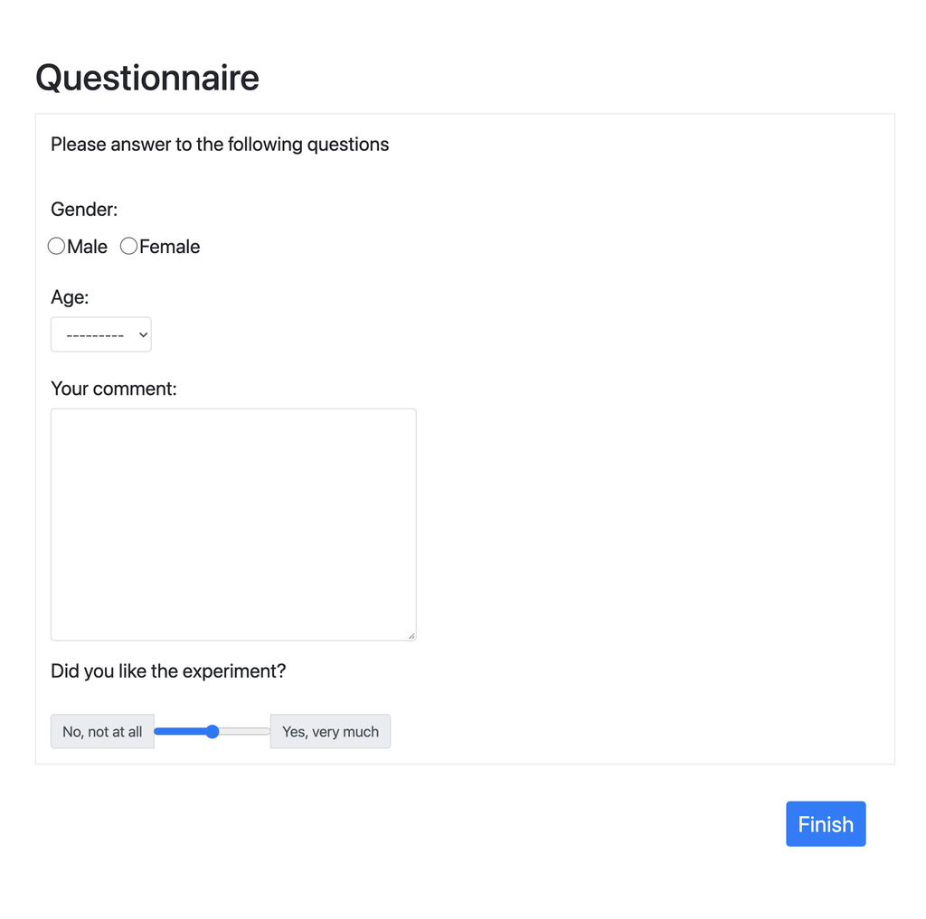

# Code

## models.py

- Import module `random`
  - Needed for payoff comoutation
- Define session constants
  - Outcomes of lotteries in MPL
- Group and Subsession are empty
  - Typical of one-shot individual decision making

```python
import random

class Constants(BaseConstants):
    name_in_url = 'MPL'
    players_per_group = None
    num_rounds = 1
    # these are the lottery payoffs, f1 and f2 refer to lottery A and f3 and f4 to lottery B
    f1 = 2.00
    f2 = 1.60
    f3 = 3.85
    f4 = 0.10

class Group(BaseGroup):
    pass

class Subsession(BaseSubsession):
    pass
```

## models.py (ii)

- In Player class we define the “templates” for data collection
  - MPL table
  - Anagraphics

```python
class Player(BasePlayer):

    # This is for main choices, each variable is one row in the choice table MPL
    HL_1 = models.PositiveIntegerField(choices=[[1, 'A'],[2, 'B']],widget=widgets.RadioSelectHorizontal)
    HL_2 = models.PositiveIntegerField(choices=[[1, 'A'],[2, 'B']],widget=widgets.RadioSelectHorizontal)
    HL_3 = models.PositiveIntegerField(choices=[[1, 'A'],[2, 'B']],widget=widgets.RadioSelectHorizontal)
    HL_4 = models.PositiveIntegerField(choices=[[1, 'A'],[2, 'B']],widget=widgets.RadioSelectHorizontal)
    HL_5 = models.PositiveIntegerField(choices=[[1, 'A'],[2, 'B']],widget=widgets.RadioSelectHorizontal)
    HL_6 = models.PositiveIntegerField(choices=[[1, 'A'],[2, 'B']],widget=widgets.RadioSelectHorizontal)
    HL_7 = models.PositiveIntegerField(choices=[[1, 'A'],[2, 'B']],widget=widgets.RadioSelectHorizontal)
    HL_8 = models.PositiveIntegerField(choices=[[1, 'A'],[2, 'B']],widget=widgets.RadioSelectHorizontal)
    HL_9 = models.PositiveIntegerField(choices=[[1, 'A'],[2, 'B']],widget=widgets.RadioSelectHorizontal)
    HL_10 = models.PositiveIntegerField(choices=[[1, 'A'],[2, 'B']],widget=widgets.RadioSelectHorizontal)

    # This is needed for the instructions
    HL = models.PositiveIntegerField(blank=True,choices=[[1, 'A'],[2, 'B']],widget=widgets.RadioSelectHorizontal)

    # These variables are collected in the final questionnaire
    sex = models.StringField(widget=widgets.RadioSelectHorizontal(),choices=['Male', 'Female'])
    age = models.IntegerField(choices = range(18,60,1))
    comment = models.TextField(label="Your comment here:")
    like = models.IntegerField(choices=[1,2,3,4,5],widget=widgets.RadioSelectHorizontal)
```

## models.py (iii)

- In Player class we compute the payoffs
  - Typical of individual decision making

```python
"""
... continue
"""

  # Define here the methods associated to Players
    # this method is needed to compute payoffs
    def set_payoff_HL(self):
        #*******************************************
        # select random row and random outcome
        #*******************************************
        self.participant.vars['HL_row'] = random.randint(1,10)
        # select one row randomly for payment (from module random)
        self.participant.vars['HL_random'] = random.randint(1,10)
        # select the number x that defines the outcome of the lottery (if x<=p, outcome is left f1 or f3, otherwise f2 or f4)
        # write it to participant.vars['HL_random']

        #*******************************************
        # select choices in correspondence to random row
        #*******************************************
        choices = [self.HL_1,self.HL_2,self.HL_3,self.HL_4,self.HL_5,self.HL_6,self.HL_7,self.HL_8,self.HL_9,self.HL_10]
        # create a list with all choices of the player (see self)
        self.participant.vars['HL_choice'] = choices[self.participant.vars['HL_row']-1]
        # select from the list the choice in correspondence to the randomly drawn row (notice the offset)
        # write it to participant.vars['HL_choice']

        #*******************************************
        # Compute here the payoffs
        #*******************************************
        if self.participant.vars['HL_random'] <= self.participant.vars['HL_row']:
        # if the random number is smaller equal than the random row
            if self.participant.vars['HL_choice'] == 1: #A
            # if the choice was A
                self.participant.vars['payoff_HL'] = Constants.f1
                # because HL_row is the same as p in the MPL
            else :
            # if the choice was B
                self.participant.vars['payoff_HL'] = Constants.f3
        else:
        # if the random number is slarger than the random row
            if self.participant.vars['HL_choice'] == 1 :#A
                # if the choice was A
                self.participant.vars['payoff_HL'] = Constants.f2
                # because HL_row is the same as p in the MPL
            else :
                self.participant.vars['payoff_HL'] = Constants.f4

        self.payoff = self.participant.vars['payoff_HL']
        # write the payoff to player.payoff
```

## pages.py

- In the instructions we have a simulation of choice protocol
  - HL (see models)
- In the main choice page we need to import a for for each row of the MPL table
- We also need the outcomes, retrieved from constants
  - Important to “declare” the variables to display with `vars_for_template()`

```python
class Instructions(Page):
    form_model = 'player'
    form_fields = ['HL'] # the demo MPL

class PageHL(Page):
# which forms are needed from class player
    form_model = 'player'
    form_fields = ['HL_1','HL_2','HL_3','HL_4','HL_5','HL_6','HL_7','HL_8','HL_9','HL_10'] # all 10 options

    # values that are to be displayed (dictionary)
    def vars_for_template(self):
        # retrieve values from constants and store them in a dictionary
        return{
        'f1':Constants.f1,
        'f2':Constants.f2,
        'f3':Constants.f3,
        'f4':Constants.f4
        }
```

## pages.py (ii)

- Before moving to the next page, we compute payoffs
  - See method *set_payoff_HL()* from models.py
  - This way we compute payoffs only once and not when browser is refreshed

```python
class PageHL(Page):

"""
[...]
"""
      # before moving to next page, compute payoffs (avoids that with refreshing payoffs are recomputed again)
    def before_next_page(self):
        # built-in method
        self.player.set_payoff_HL()# see in models in Player class
```

## pages.py (iii)

- Display outcomes
  - declare them with vars_for_template()
    - retrieve values from participant.vars and “store” them in a dictionary

```python
class OutcomeHL(Page):
# values needed to inform subjects about the actual outcome
    def vars_for_template(self):
        # retrieve values from participant.vars and store them in a dictionary
        return{
        'payoff_HL': self.player.participant.vars['payoff_HL'],#payoff
        'row': self.player.participant.vars['HL_row'], # randomly chosen row
        'value': self.participant.vars['HL_random'],# randomly chosen value to define outcome
        'choice': self.participant.vars['HL_choice'],# actual choice
        # outcomes of the selected row
        'p_A_1': self.participant.vars['HL_row'],
        'p_A_2': 10-self.participant.vars['HL_row'],
        'p_B_1': self.participant.vars['HL_row'],
        'p_B_2': 10-self.participant.vars['HL_row']
        }
```

## pages.py (iv)

- Forms in the final questionnaire retrieved from class player in models.py

```python
class Anag(Page):
# forms to retrieve individual information
    form_model = 'player'
    form_fields = ['comment','like','sex','age']# player.comment, player.like, ...
```

- Manage the sequence of pages

```python
# the coreography of pages
page_sequence = [
                    Instructions,
                    PageHL,
                    OutcomeHL,
                    Anag
]
```

# Templates

## Instructions.html

- Style elements
  - size of radio buttons

```html
{% extends "global/Page.html" %}
{% load staticfiles otree %}

{% block styles %}
   <style>
      input[type=radio] {
        transform: scale(1.5);
        margin: 12px -10px 0px -30px;
      }
   </style>
{% endblock %}
```

## Instructions.html (ii)

- Main body and demo of MPL
  - In a bs container

```html
{% block content %}

<h1>Instructions</h1>

<div class="container p-3 my-3 border" style="font-size:18pt">
  <h2> Part 1 </h2>

      <p>In the first part of the experiment you are going to choose between couples of lotteries. </p>

      <p>The following is an example of the decision setting you are facing</p>
      <table class="table">
        <thead>
          <tr>
            <th scope="col">#</th>
            <th scope="col" colspan="2" style="text-align:center">A</th>
            <th scope="col" ></th>
            <th scope="col" colspan="2"  style="text-align:center">B</th>
            <th scope="col"></th>
          </tr>
        </thead>
        <tbody>
          <tr>
            <th scope="row">1</th>
            <td > p/10 of €A<sub>1</sub>  </td>
            <td> (1-p)/10 of €A<sub>2</sub></td>
            <td style="font-weight: bold">{{ form.HL }}</td>
            <td>p/10 of €B<sub>1</sub></td>
            <td >(1-p)/10 of €B<sub>2</sub> </td>
          </tr>
        </tbody>
        </table>

<p>You must choose between lottery A and lottery B, with lottery A delivering €A<sub>1</sub> with probability p/10 and €A<sub>2</sub> with probability (1-p)/10.</p>
<p>Similarly, lottery B delivers €B<sub>1</sub> with probability p/10 and €B<sub>2</sub> with probability (1-p)/10.</p> <p>You will face 10 choices between A and B, with p changing across choices.</p>
<p>Only one of the 10 choices is chosen for payment, randomly. You will know the choice after having completed your choices.</p>
<p>All your earnings are virtual, no cash is going to be paid to you. However, choose as if the monetary stakes were real.</p>
</div>

<div class="container p-3 my-3 border" style="font-size:18pt">

<h2> Part 2 </h2>

<p>In the second part of the experiment you are asked to report some information about you.</p>

</div>
```

## Instructions.html

- The button to leave the page
  - Put it to the right with a container

```html
"""
[...]
"""

<div class="container" style="font-size:18pt">
  <div class="row">
    &nbsp;
  </div>
  <div class="row" style="padding-left:135px;">
    <div class="col-md-10">

    </div>
    <div class="col-md-2">
      <button name="btn_submit" value="True" class="btn btn-primary btn-large">
         <span style="font-size:18pt">Continue</span>
     </button>
    </div>
  </div>
</div>


</body></html>

{% endblock %}
```

## PageHL.html

Structure similar to `Instructions.html`

## OutcomeHL.html

```html
<h1> Results </h1>

<div class="container p-3 my-3 border" style="font-size:14pt">
        <p> <b>Row #{{row}}</b> was randomly selected for payment.</p>

        <table class="table">
            <thead>
                <tr>
                    <th scope="col">#</th>
                    <th scope="col" colspan="2" style="text-align:center">A</th>
                    <th scope="col" ></th>
                    <th scope="col" colspan="2"  style="text-align:center">B</th>
                    <th scope="col"></th>
                </tr>
            </thead>
        <tr>
            <th scope="row">{{row}}</th>
            <td>{{p_A_1}}/10 of €{{Constants.f1}} </td>
            <td> {{p_A_2}}/10 of €{{Constants.f2}}</td>
        <td></td>
            <td>{{p_B_1}}/10 of €{{Constants.f3}}</td>
            <td>{{p_B_2}}/10 of €{{Constants.f4}} </td>
        </tr>
        </table>
<!-- The lottery chosen -->
        <p>You chose
      {% if choice == 1 %}
    <b>Lottery A.</b>
        {% else %}
    <b>Lottery B.</b>
        {% endif %}
</p>

<p> The randomly drawn value that defines the outcome of the lottery is {{value}}.</p>

<p> Thus, you earn <b>{{payoff_HL}}</b></p>
</div>
```

- The randomly chosen row is displayed `{row}`
- They are informed about the lottery chosen `{% if choice == 1 %} ... {% endif %}`

## Questionnaire

```html
<h1> Questionnaire </h1>

<div class="container p-3 my-3 border" style="font-size:16pt">
    Please answer to the following questions
    <br>
    <br>
{% formfield player.sex label="Gender" %}
{% formfield player.age label="Age" %}
{% formfield player.comment label="Your comment" %}

Did you like the experiment?
<br>
<br>
<div class="input-group">
    <div class="input-group-prepend">
        <span class="input-group-text">No, not at all</span>
    </div>
    <input type="range" name="like" min="1" max="5" step="1">
    <div class="input-group-append">
        <span class="input-group-text">Yes, very much</span>
    </div>
    </div>
</div>

{{ form.like.errors }}
```

- Several form fields
- A pure html inout form
  - Add `{{ form.like.errors }}` to “catch” possible errors in the page

# Appendix

## Assignments

- **Easy**
  - Add a field to the final questionnaire of MPL
    - Nationality
- **Reasonably easy**
  - Add a third option in each row: “Indifferent”
    - The choice should look like

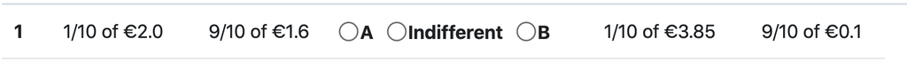

- **Not so difficult**
  - Change the protocol of the MPL
    - Instead of a choice for each row, participants report only the row in which they switch from A to B
      - e.g., the sequence AAAAABBBBB becomes a value = 6

## Assignments (ii)

- **Challenging**
  - Run the following app and test it

Download real_effort.zip

- Participants are asked to count the number of zeroes in a series of tables in 120 seconds
  - For each table correctly solved they earn 1 point
- Make the following changes
  1. Make tables of size 36 (instead of 48)
  2. Increase the time available to 180 seconds
  3. Ask participants to count the 1s rather than the 0s

## OTree code

- The oTree app of this lecture:
- Inputs
  - Download inputs.zip
- MPL
  - Download MPL.zip

## An alternative approach to MPL

- The `PageHL.html` template can be written in a more compact form with `for`
- Main table

```html
<table class="table">
  <thead>
    <tr>
      <th scope="col" colspan="1">Lottery</th>
      <th scope="col" colspan="2" style="text-align:center">A</th>
      <th scope="col" colspan="1" style="text-align:center"></th>
      <th scope="col" colspan="2" style="text-align:center">B</th>
      <th scope="col" colspan="2" style="text-align:center">La mia scelta</th>
    </tr>
  </thead>

  {% for i in Lott %}
  <tr>
      {% for j in i %}
        <td style="text-align:center">
        {{ j }}
        </td>
      {% endfor %}
      <td style="text-align:center">
        &nbsp; &nbsp;  A<input type="radio" id="HL_{{forloop.counter}}" name="HL_{{forloop.counter}}" value=1>
      </td>
      <td style="text-align:center">
       &nbsp;&nbsp;  B<input type="radio" id="HL_{{forloop.counter}}" name="HL_{{forloop.counter}}" value=2>
      </td>
  </tr>
  {% endfor %}
</table>
```

## An alternative approach to MPL (ii)

In `pages.py` create a list of choices - Each choice is a list itself

```python
class PageHL_2(Page):
    form_model = 'player'
    form_fields = ['HL_1','HL_2','HL_3','HL_4','HL_5','HL_6','HL_7','HL_8','HL_9','HL_10'] # all 10 options

    def vars_for_template(self):
        Lotteries = []
        for i in range(1,11):
            Lotteries.append([i,str(i)+"/10 of €"+str(Constants.f1), str(10-i)+"/10 of €"+str(Constants.f2),"", str(i)+"/10 of €"+str(Constants.f3), str(10-i)+"/10 of €"+str(Constants.f4)])
        return{
        'Lott': Lotteries
        }
```